# Gamma Distribution

Elena Sophia

January 22, 2017

Gamma distribution is a two-parameter family of continuous probability distributions. The common exponential distribution and chi-squared distribution are special cases of the gamma distribution.

Parameters:

- $k$ > 0 shape
- $theta$ > 0 scale

PDF: ${\frac {1}{\Gamma (k)\theta ^{k}}}x^{k\,-\,1}e^{-{\frac {x}{\theta }}}$

Mean: $\scriptstyle \mathbf {E} [X]=k\theta$

Variance: $\scriptstyle\operatorname{Var}[ X] = k\theta^2$

Source: Wikipedia

# Gamma Distribution Applications

- model errors in multi-level Poisson regression models, because the combination of the Poisson distribution and a gamma distribution is a negative binomial distribution.
- model the multi-path fading of signal power in wireless communication
- describe the distribution of inter-spike intervals in neuroscience
- model aggregate insurance claims and the amount of rainfall accumulated in a reservoir
- in bacterial gene expression, the copy number of a constitutively expressed protein often follows the gamma distribution.
- in genomics, the gamma distribution was applied in peak calling step in ChIP-chip and ChIP-seq data analysis.

Source: Wikipedia

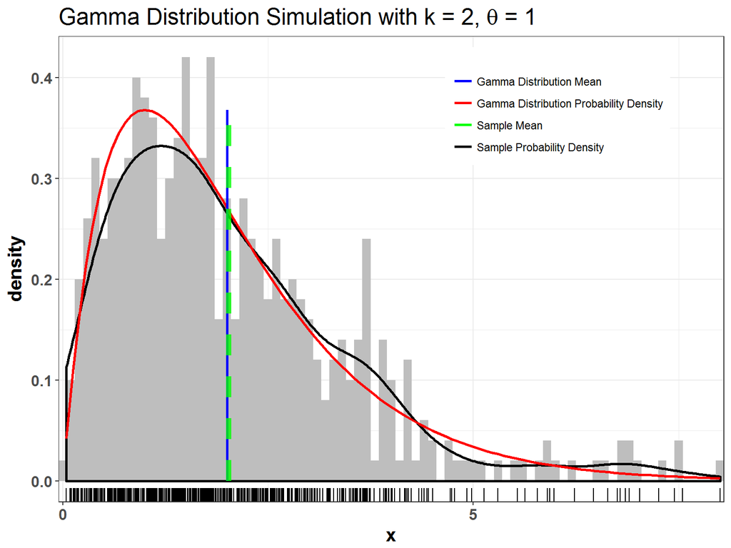

The plot on the previous slide shows theoretical gamma distribution with shape $\k$ = 2 and scale $\theta$ = 1 and corresponding $\mu$ = 2 and $\sigma$ = 1.41. For 500 iid random gamma variables sample distribution mean $\bar{X}$ = 2.02 and standard error S = 1.44 are close to the underlying population parameters. The sample density (black line on the plot) follows that of the gamma distribution (shown in red); theoretical and sample means are shown as blue and dashed green line.